# R para analizar datos lingüísticos y facilitar investigaciones reproducibles

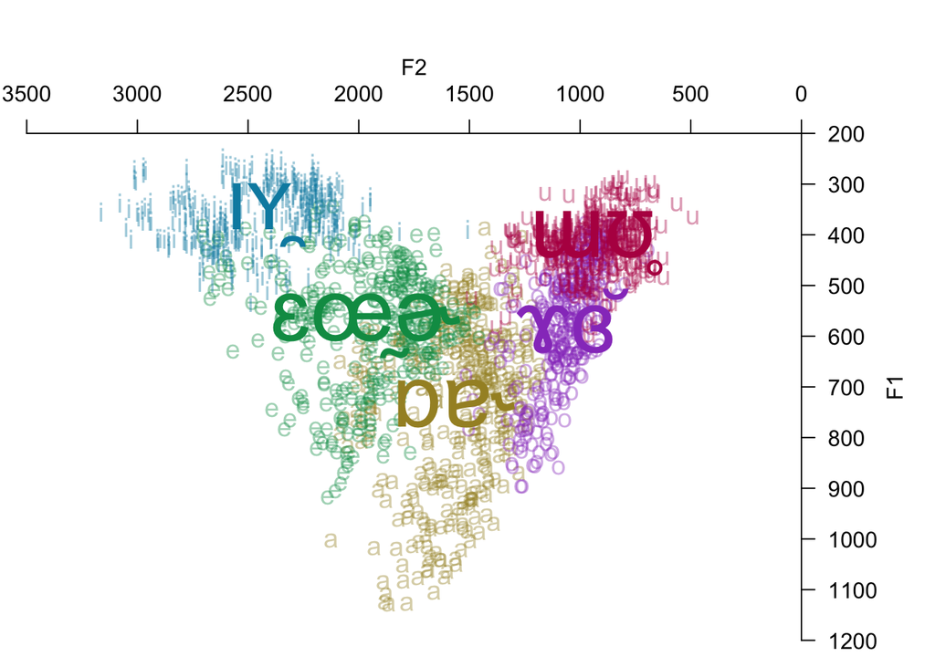

> Las vocales del indonesio visualizados con el paquete [phonR](http://drammock.github.io/phonR/) McCloy(2016)

# Información del curso

### Tutor:

Max Carey

### Semestre:

2018-2 (1 de febrero al 24 de mayo) [¡Inscríbete!](https://goo.gl/forms/ty6TgMkmSIMpqNb82)

### Horario y lugar:

Viernes 15:00-17:00, Unidad de Posgrado CU-UNAM, J-201 (Sala de cómputo)

### Número de créditos:

Este curso no otorgará créditos con valor curricular.

### Lenguas:

Los materiales del curso serán en inglés y las sesiones se darán en español.

### Número de horas durante el semestre:

`60`

### Objetivo general

Familiarizar al alumno, de manera muy práctica, con la programación en R, Estadística con R, y otras herramientas y conceptos básicos de la informática para que puedan aplicarlos a sus futuros y actuales proyectos de investigación.

# Temas

| Unidad | Tema | Horas_Teóricas | Horas_Prácticas |
| --- | --- | --- | --- |
| 1 | Herramientas y conceptos básicos de la informática | 0 | 10 |
| 2 | R Studio y El Tidyverse | 0 | 6 |
| 3 | Programación básica con R | 0 | 14 |
| 4 | Estadística descriptiva e inferencial con R | 0 | 20 |
| 5 | Lingüística de corpus con R y otras herramientas | 0 | 10 |

# Subtemas

### **Unidad 2**

- Dplyr para manipulación de datos, ggplot2 para la visualización de datos (4 horas de datacamp.com en casa y 2 horas de taller)

### **Unidad 3**

- Cómo mostrar output en R, (programas del tipo “hello world”) las estructuras de control (condicionales, iteraciones), en R variables, funciones, funciones de la familia apply() de R (10 horas de datacamp.com en casa y 4 horas de taller)

# Bibliografía básica

1. Sierra Martínez, G. E. (2017). Introducción a los corpus lingüísticos. Instituto de Ingeniería. UNAM
2. Gries, S. T. (2017). Quantitative corpus linguistics with R: a practical introduction (Segunda Edición). New York: Routledge, Taylor & Francis Group
3. Adolphs, S. (2011). Corpus Linguistics. En J. Simpson (Ed.), The Routledge handbook of applied linguistics (1st ed). Milton Park, Abingdon, [UK]; New York: Routledge.
4. Weisser, M. (2016). Practical corpus linguistics: an introduction to corpus-based language analysis. Chichester, West Sussex [England]; Malden, MA: Wiley Blackwell.

# Estrategias didácticas

Exposición oral

Exposición audiovisual

Ejercicios dentro de clase

Ejercicios fuera del aula

Lecturas obligatorias

Trabajo de Investigación

# Mecanismos de evaluación del aprendizaje de los alumnos:

Exámenes Parciales

Examen final escrito

Trabajos y tareas fuera del aula

Exposición de seminarios por los alumnos

Participación en clase

Asistencia

Seminario

Ejercicios fuera de aula

# Perfil profesiográfico:

Licenciado en lingüística romance, experiencia profesional enseñando a programar, publicaciones y tesis que utilizaron R, Diplomado en Programación para aplicaciones web, experiencia profesional en programación para el análisis de datos

# Referencias

Daniel R. McCloy (2016). phonR: tools for phoneticians and phonologists. R package version 1.0-7.